# W3cubDocs

/GTK 4.0

# GtkTreeView

GtkTreeView — A widget for displaying both trees and lists

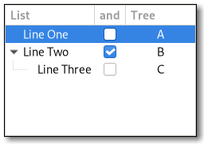

## Functions

| gboolean | (*GtkTreeViewColumnDropFunc) () |
| --- | --- |
| void | (*GtkTreeViewMappingFunc) () |
| gboolean | (*GtkTreeViewSearchEqualFunc) () |
| GtkWidget * | gtk_tree_view_new () |
| int | gtk_tree_view_get_level_indentation () |
| gboolean | gtk_tree_view_get_show_expanders () |
| void | gtk_tree_view_set_level_indentation () |
| void | gtk_tree_view_set_show_expanders () |
| GtkWidget * | gtk_tree_view_new_with_model () |
| GtkTreeModel * | gtk_tree_view_get_model () |
| void | gtk_tree_view_set_model () |
| GtkTreeSelection * | gtk_tree_view_get_selection () |
| gboolean | gtk_tree_view_get_headers_visible () |
| void | gtk_tree_view_set_headers_visible () |
| void | gtk_tree_view_columns_autosize () |
| gboolean | gtk_tree_view_get_headers_clickable () |
| void | gtk_tree_view_set_headers_clickable () |
| void | gtk_tree_view_set_activate_on_single_click () |
| gboolean | gtk_tree_view_get_activate_on_single_click () |
| int | gtk_tree_view_append_column () |
| int | gtk_tree_view_remove_column () |
| int | gtk_tree_view_insert_column () |
| int | gtk_tree_view_insert_column_with_attributes () |
| int | gtk_tree_view_insert_column_with_data_func () |
| guint | gtk_tree_view_get_n_columns () |
| GtkTreeViewColumn * | gtk_tree_view_get_column () |
| GList * | gtk_tree_view_get_columns () |
| void | gtk_tree_view_move_column_after () |
| void | gtk_tree_view_set_expander_column () |
| GtkTreeViewColumn * | gtk_tree_view_get_expander_column () |
| void | gtk_tree_view_set_column_drag_function () |

[output cut: 64 more lines]

## Properties

| gboolean | activate-on-single-click | Read / Write |
| --- | --- | --- |
| GtkTreeViewGridLines | enable-grid-lines | Read / Write |
| gboolean | enable-search | Read / Write |
| gboolean | enable-tree-lines | Read / Write |
| GtkTreeViewColumn * | expander-column | Read / Write |
| gboolean | fixed-height-mode | Read / Write |
| gboolean | headers-clickable | Read / Write |
| gboolean | headers-visible | Read / Write |
| gboolean | hover-expand | Read / Write |
| gboolean | hover-selection | Read / Write |
| int | level-indentation | Read / Write |
| GtkTreeModel * | model | Read / Write |
| gboolean | reorderable | Read / Write |
| gboolean | rubber-banding | Read / Write |
| int | search-column | Read / Write |
| gboolean | show-expanders | Read / Write |
| int | tooltip-column | Read / Write |

## Signals

| void | columns-changed | Run Last |
| --- | --- | --- |
| void | cursor-changed | Run Last |
| gboolean | expand-collapse-cursor-row | Action |
| gboolean | move-cursor | Action |
| void | row-activated | Action |
| void | row-collapsed | Run Last |
| void | row-expanded | Run Last |
| gboolean | select-all | Action |
| gboolean | select-cursor-parent | Action |
| gboolean | select-cursor-row | Action |
| gboolean | start-interactive-search | Action |
| gboolean | test-collapse-row | Run Last |
| gboolean | test-expand-row | Run Last |
| gboolean | toggle-cursor-row | Action |
| gboolean | unselect-all | Action |

## Types and Values

| struct | GtkTreeView |
| --- | --- |
| enum | GtkTreeViewDropPosition |
| enum | GtkTreeViewGridLines |

## Object Hierarchy

```
    GObject
    ╰── GInitiallyUnowned
        ╰── GtkWidget
            ╰── GtkTreeView
```

## Implemented Interfaces

GtkTreeView implements GtkAccessible, GtkBuildable, GtkConstraintTarget and GtkScrollable.

## Includes

```
#include <gtk/gtk.h>
```

## Description

Widget that displays any object that implements the GtkTreeModel interface.

Please refer to the tree widget conceptual overview for an overview of all the objects and data types related to the tree widget and how they work together.

Several different coordinate systems are exposed in the GtkTreeView API. These are:

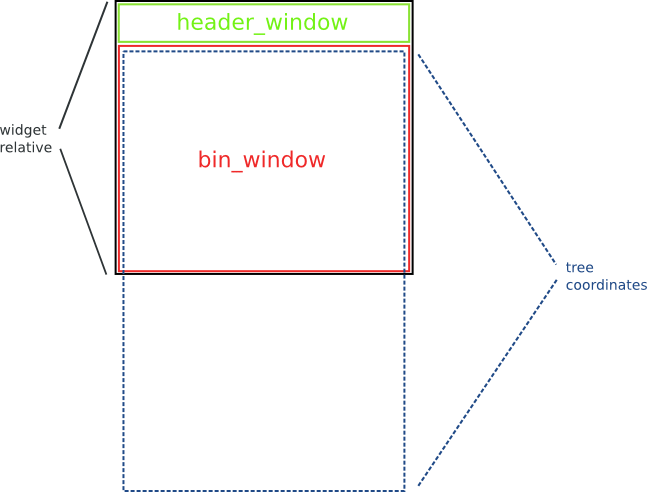

Coordinate systems in GtkTreeView API:

- Widget coordinates: Coordinates relative to the widget (usually `widget->window`).
- Bin window coordinates: Coordinates relative to the window that GtkTreeView renders to.
- Tree coordinates: Coordinates relative to the entire scrollable area of GtkTreeView. These coordinates start at (0, 0) for row 0 of the tree.

Several functions are available for converting between the different coordinate systems. The most common translations are between widget and bin window coordinates and between bin window and tree coordinates. For the former you can use `gtk_tree_view_convert_widget_to_bin_window_coords()` (and vice versa), for the latter `gtk_tree_view_convert_bin_window_to_tree_coords()` (and vice versa).

### GtkTreeView as GtkBuildable

The GtkTreeView implementation of the GtkBuildable interface accepts GtkTreeViewColumn objects as <child> elements and exposes the internal GtkTreeSelection in UI definitions.

An example of a UI definition fragment with GtkTreeView:

```
<object class="GtkTreeView" id="treeview">
  <property name="model">liststore1</property>
  <child>
    <object class="GtkTreeViewColumn" id="test-column">
      <property name="title">Test</property>
      <child>
        <object class="GtkCellRendererText" id="test-renderer"/>
        <attributes>
          <attribute name="text">1</attribute>
        </attributes>
      </child>
    </object>
  </child>
  <child internal-child="selection">
    <object class="GtkTreeSelection" id="selection">
      <signal name="changed" handler="on_treeview_selection_changed"/>
    </object>
  </child>
</object>
```

GtkTreeView has a main CSS node with name treeview and style class .view. It has a subnode with name header, which is the parent for all the column header widgets' CSS nodes.

For rubberband selection, a subnode with name rubberband is used.

For the drop target location during DND, a subnode with name dndtarget is used.

## Functions

### GtkTreeViewColumnDropFunc ()

```
gboolean
(*GtkTreeViewColumnDropFunc) (GtkTreeView *tree_view,
                              GtkTreeViewColumn *column,
                              GtkTreeViewColumn *prev_column,
                              GtkTreeViewColumn *next_column,
                              gpointer data);
```

Function type for determining whether *`column`* can be dropped in a particular spot (as determined by *`prev_column`* and *`next_column`* ). In left to right locales, *`prev_column`* is on the left of the potential drop spot, and *`next_column`* is on the right. In right to left mode, this is reversed. This function should return `TRUE` if the spot is a valid drop spot. Please note that returning `TRUE` does not actually indicate that the column drop was made, but is meant only to indicate a possible drop spot to the user.

#### Parameters

| tree_view | A GtkTreeView |  |
| --- | --- | --- |
| column | The GtkTreeViewColumn being dragged |  |
| prev_column | A GtkTreeViewColumn on one side of *`column`* |  |
| next_column | A GtkTreeViewColumn on the other side of *`column`* |  |
| data | user data. | [closure] |

#### Returns

`TRUE`, if *`column`* can be dropped in this spot

### GtkTreeViewMappingFunc ()

```
void
(*GtkTreeViewMappingFunc) (GtkTreeView *tree_view,
                           GtkTreePath *path,
                           gpointer user_data);
```

Function used for `gtk_tree_view_map_expanded_rows()`.

#### Parameters

| tree_view | A GtkTreeView |  |
| --- | --- | --- |
| path | The path that’s expanded |  |
| user_data | user data |  |

### GtkTreeViewSearchEqualFunc ()

```
gboolean
(*GtkTreeViewSearchEqualFunc) (GtkTreeModel *model,
                               int column,
                               const char *key,
                               GtkTreeIter *iter,
                               gpointer search_data);
```

A function used for checking whether a row in *`model`* matches a search key string entered by the user. Note the return value is reversed from what you would normally expect, though it has some similarity to `strcmp()` returning 0 for equal strings.

#### Parameters

| model | the GtkTreeModel being searched |  |
| --- | --- | --- |
| column | the search column set by `gtk_tree_view_set_search_column()` |  |
| key | the key string to compare with |  |
| iter | a GtkTreeIter pointing the row of *`model`* that should be compared with *`key`* . |  |
| search_data | user data from `gtk_tree_view_set_search_equal_func()`. | [closure] |

#### Returns

`FALSE` if the row matches, `TRUE` otherwise.

### gtk_tree_view_new ()

```
GtkWidget *
gtk_tree_view_new (void);
```

Creates a new GtkTreeView widget.

#### Returns

A newly created GtkTreeView widget.

### gtk_tree_view_get_level_indentation ()

```
int
gtk_tree_view_get_level_indentation (GtkTreeView *tree_view);
```

Returns the amount, in pixels, of extra indentation for child levels in *`tree_view`* .

#### Parameters

| tree_view | a GtkTreeView. |  |
| --- | --- | --- |

#### Returns

the amount of extra indentation for child levels in *`tree_view`* . A return value of 0 means that this feature is disabled.

### gtk_tree_view_get_show_expanders ()

```
gboolean
gtk_tree_view_get_show_expanders (GtkTreeView *tree_view);
```

Returns whether or not expanders are drawn in *`tree_view`* .

#### Parameters

| tree_view | a GtkTreeView. |  |
| --- | --- | --- |

#### Returns

`TRUE` if expanders are drawn in *`tree_view`* , `FALSE` otherwise.

### gtk_tree_view_set_level_indentation ()

```
void
gtk_tree_view_set_level_indentation (GtkTreeView *tree_view,
                                     int indentation);
```

Sets the amount of extra indentation for child levels to use in *`tree_view`* in addition to the default indentation. The value should be specified in pixels, a value of 0 disables this feature and in this case only the default indentation will be used. This does not have any visible effects for lists.

#### Parameters

| tree_view | a GtkTreeView |  |
| --- | --- | --- |
| indentation | the amount, in pixels, of extra indentation in *`tree_view`* . |  |

### gtk_tree_view_set_show_expanders ()

```
void
gtk_tree_view_set_show_expanders (GtkTreeView *tree_view,
                                  gboolean enabled);
```

Sets whether to draw and enable expanders and indent child rows in *`tree_view`* . When disabled there will be no expanders visible in trees and there will be no way to expand and collapse rows by default. Also note that hiding the expanders will disable the default indentation. You can set a custom indentation in this case using `gtk_tree_view_set_level_indentation()`. This does not have any visible effects for lists.

#### Parameters

| tree_view | a GtkTreeView |  |
| --- | --- | --- |
| enabled | `TRUE` to enable expander drawing, `FALSE` otherwise. |  |

### gtk_tree_view_new_with_model ()

```
GtkWidget *
gtk_tree_view_new_with_model (GtkTreeModel *model);
```

Creates a new GtkTreeView widget with the model initialized to *`model`* .

#### Parameters

| model | the model. |  |
| --- | --- | --- |

#### Returns

A newly created GtkTreeView widget.

### gtk_tree_view_get_model ()

```
GtkTreeModel *
gtk_tree_view_get_model (GtkTreeView *tree_view);
```

Returns the model the GtkTreeView is based on. Returns `NULL` if the model is unset.

#### Parameters

| tree_view | a GtkTreeView |  |
| --- | --- | --- |

#### Returns

A GtkTreeModel, or `NULL` if none is currently being used.

[transfer none][nullable]

### gtk_tree_view_set_model ()

```
void
gtk_tree_view_set_model (GtkTreeView *tree_view,
                         GtkTreeModel *model);
```

Sets the model for a GtkTreeView. If the *`tree_view`* already has a model set, it will remove it before setting the new model. If *`model`* is `NULL`, then it will unset the old model.

#### Parameters

| tree_view | A GtkTreeView. |  |
| --- | --- | --- |
| model | The model. | [allow-none] |

### gtk_tree_view_get_selection ()

```
GtkTreeSelection *
gtk_tree_view_get_selection (GtkTreeView *tree_view);
```

Gets the GtkTreeSelection associated with *`tree_view`* .

#### Parameters

| tree_view | A GtkTreeView. |  |
| --- | --- | --- |

#### Returns

A GtkTreeSelection object.

[transfer none]

### gtk_tree_view_get_headers_visible ()

```
gboolean
gtk_tree_view_get_headers_visible (GtkTreeView *tree_view);
```

Returns `TRUE` if the headers on the *`tree_view`* are visible.

#### Parameters

| tree_view | A GtkTreeView. |  |
| --- | --- | --- |

#### Returns

Whether the headers are visible or not.

### gtk_tree_view_set_headers_visible ()

```
void
gtk_tree_view_set_headers_visible (GtkTreeView *tree_view,
                                   gboolean headers_visible);
```

Sets the visibility state of the headers.

#### Parameters

| tree_view | A GtkTreeView. |  |
| --- | --- | --- |
| headers_visible | `TRUE` if the headers are visible |  |

### gtk_tree_view_columns_autosize ()

```
void
gtk_tree_view_columns_autosize (GtkTreeView *tree_view);
```

Resizes all columns to their optimal width. Only works after the treeview has been realized.

#### Parameters

| tree_view | A GtkTreeView. |  |
| --- | --- | --- |

### gtk_tree_view_get_headers_clickable ()

```
gboolean
gtk_tree_view_get_headers_clickable (GtkTreeView *tree_view);
```

Returns whether all header columns are clickable.

#### Parameters

| tree_view | A GtkTreeView. |  |
| --- | --- | --- |

#### Returns

`TRUE` if all header columns are clickable, otherwise `FALSE`

### gtk_tree_view_set_headers_clickable ()

```
void
gtk_tree_view_set_headers_clickable (GtkTreeView *tree_view,
                                     gboolean setting);
```

Allow the column title buttons to be clicked.

#### Parameters

| tree_view | A GtkTreeView. |  |
| --- | --- | --- |
| setting | `TRUE` if the columns are clickable. |  |

### gtk_tree_view_set_activate_on_single_click ()

```
void
gtk_tree_view_set_activate_on_single_click
                               (GtkTreeView *tree_view,
                                gboolean single);
```

Cause the “row-activated” signal to be emitted on a single click instead of a double click.

#### Parameters

| tree_view | a GtkTreeView |  |
| --- | --- | --- |
| single | `TRUE` to emit row-activated on a single click |  |

### gtk_tree_view_get_activate_on_single_click ()

```
gboolean
gtk_tree_view_get_activate_on_single_click
                               (GtkTreeView *tree_view);
```

Gets the setting set by `gtk_tree_view_set_activate_on_single_click()`.

#### Parameters

| tree_view | a GtkTreeView |  |
| --- | --- | --- |

#### Returns

`TRUE` if row-activated will be emitted on a single click

### gtk_tree_view_append_column ()

```
int
gtk_tree_view_append_column (GtkTreeView *tree_view,
                             GtkTreeViewColumn *column);
```

Appends *`column`* to the list of columns. If *`tree_view`* has “fixed_height” mode enabled, then *`column`* must have its “sizing” property set to be GTK_TREE_VIEW_COLUMN_FIXED.

#### Parameters

| tree_view | A GtkTreeView. |  |
| --- | --- | --- |
| column | The GtkTreeViewColumn to add. |  |

#### Returns

The number of columns in *`tree_view`* after appending.

### gtk_tree_view_remove_column ()

```
int
gtk_tree_view_remove_column (GtkTreeView *tree_view,
                             GtkTreeViewColumn *column);
```

Removes *`column`* from *`tree_view`* .

#### Parameters

| tree_view | A GtkTreeView. |  |
| --- | --- | --- |
| column | The GtkTreeViewColumn to remove. |  |

#### Returns

The number of columns in *`tree_view`* after removing.

### gtk_tree_view_insert_column ()

```
int
gtk_tree_view_insert_column (GtkTreeView *tree_view,
                             GtkTreeViewColumn *column,
                             int position);
```

This inserts the *`column`* into the *`tree_view`* at *`position`* . If *`position`* is -1, then the column is inserted at the end. If *`tree_view`* has “fixed_height” mode enabled, then *`column`* must have its “sizing” property set to be GTK_TREE_VIEW_COLUMN_FIXED.

#### Parameters

| tree_view | A GtkTreeView. |  |
| --- | --- | --- |
| column | The GtkTreeViewColumn to be inserted. |  |
| position | The position to insert *`column`* in. |  |

#### Returns

The number of columns in *`tree_view`* after insertion.

### gtk_tree_view_insert_column_with_attributes ()

```
int
gtk_tree_view_insert_column_with_attributes
                               (GtkTreeView *tree_view,
                                int position,
                                const char *title,
                                GtkCellRenderer *cell,
                                ...);
```

Creates a new GtkTreeViewColumn and inserts it into the *`tree_view`* at *`position`* . If *`position`* is -1, then the newly created column is inserted at the end. The column is initialized with the attributes given. If *`tree_view`* has “fixed_height” mode enabled, then the new column will have its sizing property set to be GTK_TREE_VIEW_COLUMN_FIXED.

#### Parameters

| tree_view | A GtkTreeView |  |
| --- | --- | --- |
| position | The position to insert the new column in |  |
| title | The title to set the header to |  |
| cell | The GtkCellRenderer |  |
| ... | A `NULL`-terminated list of attributes |  |

#### Returns

The number of columns in *`tree_view`* after insertion.

### gtk_tree_view_insert_column_with_data_func ()

```
int
gtk_tree_view_insert_column_with_data_func
                               (GtkTreeView *tree_view,
                                int position,
                                const char *title,
                                GtkCellRenderer *cell,
                                GtkTreeCellDataFunc func,
                                gpointer data,
                                GDestroyNotify dnotify);
```

Convenience function that inserts a new column into the GtkTreeView with the given cell renderer and a GtkTreeCellDataFunc to set cell renderer attributes (normally using data from the model). See also `gtk_tree_view_column_set_cell_data_func()`, `gtk_tree_view_column_pack_start()`. If *`tree_view`* has “fixed_height” mode enabled, then the new column will have its “sizing” property set to be GTK_TREE_VIEW_COLUMN_FIXED.

#### Parameters

| tree_view | a GtkTreeView |  |
| --- | --- | --- |
| position | Position to insert, -1 for append |  |
| title | column title |  |
| cell | cell renderer for column |  |
| func | function to set attributes of cell renderer |  |
| data | data for *`func`* |  |
| dnotify | destroy notifier for *`data`* |  |

#### Returns

number of columns in the tree view post-insert

### gtk_tree_view_get_n_columns ()

```
guint
gtk_tree_view_get_n_columns (GtkTreeView *tree_view);
```

Queries the number of columns in the given *`tree_view`* .

#### Parameters

| tree_view | a GtkTreeView |  |
| --- | --- | --- |

#### Returns

The number of columns in the *`tree_view`*

### gtk_tree_view_get_column ()

```
GtkTreeViewColumn *
gtk_tree_view_get_column (GtkTreeView *tree_view,
                          int n);
```

Gets the GtkTreeViewColumn at the given position in the tree_view.

#### Parameters

| tree_view | A GtkTreeView. |  |
| --- | --- | --- |
| n | The position of the column, counting from 0. |  |

#### Returns

The GtkTreeViewColumn, or `NULL` if the position is outside the range of columns.

[nullable][transfer none]

### gtk_tree_view_get_columns ()

```
GList *
gtk_tree_view_get_columns (GtkTreeView *tree_view);
```

Returns a GList of all the GtkTreeViewColumn s currently in *`tree_view`* . The returned list must be freed with `g_list_free()`.

#### Parameters

| tree_view | A GtkTreeView |  |
| --- | --- | --- |

#### Returns

A list of GtkTreeViewColumn s.

[element-type GtkTreeViewColumn][transfer container]

### gtk_tree_view_move_column_after ()

```
void
gtk_tree_view_move_column_after (GtkTreeView *tree_view,
                                 GtkTreeViewColumn *column,
                                 GtkTreeViewColumn *base_column);
```

Moves *`column`* to be after to *`base_column`* . If *`base_column`* is `NULL`, then *`column`* is placed in the first position.

#### Parameters

| tree_view | A GtkTreeView |  |
| --- | --- | --- |
| column | The GtkTreeViewColumn to be moved. |  |
| base_column | The GtkTreeViewColumn to be moved relative to, or `NULL`. | [allow-none] |

### gtk_tree_view_set_expander_column ()

```
void
gtk_tree_view_set_expander_column (GtkTreeView *tree_view,
                                   GtkTreeViewColumn *column);
```

Sets the column to draw the expander arrow at. It must be in *`tree_view`* . If *`column`* is `NULL`, then the expander arrow is always at the first visible column.

If you do not want expander arrow to appear in your tree, set the expander column to a hidden column.

#### Parameters

| tree_view | A GtkTreeView |  |
| --- | --- | --- |
| column | `NULL`, or the column to draw the expander arrow at. | [nullable] |

### gtk_tree_view_get_expander_column ()

```
GtkTreeViewColumn *
gtk_tree_view_get_expander_column (GtkTreeView *tree_view);
```

Returns the column that is the current expander column, or `NULL` if none has been set. This column has the expander arrow drawn next to it.

#### Parameters

| tree_view | A GtkTreeView |  |
| --- | --- | --- |

#### Returns

The expander column.

[transfer none][nullable]

### gtk_tree_view_set_column_drag_function ()

```
void
gtk_tree_view_set_column_drag_function
                               (GtkTreeView *tree_view,
                                GtkTreeViewColumnDropFunc func,
                                gpointer user_data,
                                GDestroyNotify destroy);
```

Sets a user function for determining where a column may be dropped when dragged. This function is called on every column pair in turn at the beginning of a column drag to determine where a drop can take place. The arguments passed to *`func`* are: the *`tree_view`* , the GtkTreeViewColumn being dragged, the two GtkTreeViewColumn s determining the drop spot, and *`user_data`* . If either of the GtkTreeViewColumn arguments for the drop spot are `NULL`, then they indicate an edge. If *`func`* is set to be `NULL`, then *`tree_view`* reverts to the default behavior of allowing all columns to be dropped everywhere.

#### Parameters

| tree_view | A GtkTreeView. |  |
| --- | --- | --- |
| func | A function to determine which columns are reorderable, or `NULL`. | [allow-none] |
| user_data | User data to be passed to *`func`* , or `NULL`. | [closure] |
| destroy | Destroy notifier for *`user_data`* , or `NULL`. | [allow-none] |

### gtk_tree_view_scroll_to_point ()

```
void
gtk_tree_view_scroll_to_point (GtkTreeView *tree_view,
                               int tree_x,
                               int tree_y);
```

Scrolls the tree view such that the top-left corner of the visible area is *`tree_x`* , *`tree_y`* , where *`tree_x`* and *`tree_y`* are specified in tree coordinates. The *`tree_view`* must be realized before this function is called. If it isn't, you probably want to be using `gtk_tree_view_scroll_to_cell()`.

If either *`tree_x`* or *`tree_y`* are -1, then that direction isn’t scrolled.

#### Parameters

| tree_view | a GtkTreeView |  |
| --- | --- | --- |
| tree_x | X coordinate of new top-left pixel of visible area, or -1 |  |
| tree_y | Y coordinate of new top-left pixel of visible area, or -1 |  |

### gtk_tree_view_scroll_to_cell ()

```
void
gtk_tree_view_scroll_to_cell (GtkTreeView *tree_view,
                              GtkTreePath *path,
                              GtkTreeViewColumn *column,
                              gboolean use_align,
                              float row_align,
                              float col_align);
```

Moves the alignments of *`tree_view`* to the position specified by *`column`* and *`path`* . If *`column`* is `NULL`, then no horizontal scrolling occurs. Likewise, if *`path`* is `NULL` no vertical scrolling occurs. At a minimum, one of *`column`* or *`path`* need to be non-`NULL`. *`row_align`* determines where the row is placed, and *`col_align`* determines where *`column`* is placed. Both are expected to be between 0.0 and 1.0. 0.0 means left/top alignment, 1.0 means right/bottom alignment, 0.5 means center.

If *`use_align`* is `FALSE`, then the alignment arguments are ignored, and the tree does the minimum amount of work to scroll the cell onto the screen. This means that the cell will be scrolled to the edge closest to its current position. If the cell is currently visible on the screen, nothing is done.

This function only works if the model is set, and *`path`* is a valid row on the model. If the model changes before the *`tree_view`* is realized, the centered path will be modified to reflect this change.

#### Parameters

| tree_view | A GtkTreeView. |  |
| --- | --- | --- |
| path | The path of the row to move to, or `NULL`. | [allow-none] |
| column | The GtkTreeViewColumn to move horizontally to, or `NULL`. | [allow-none] |
| use_align | whether to use alignment arguments, or `FALSE`. |  |
| row_align | The vertical alignment of the row specified by *`path`* . |  |
| col_align | The horizontal alignment of the column specified by *`column`* . |  |

### gtk_tree_view_set_cursor ()

```
void
gtk_tree_view_set_cursor (GtkTreeView *tree_view,
                          GtkTreePath *path,
                          GtkTreeViewColumn *focus_column,
                          gboolean start_editing);
```

Sets the current keyboard focus to be at *`path`* , and selects it. This is useful when you want to focus the user’s attention on a particular row. If *`focus_column`* is not `NULL`, then focus is given to the column specified by it. Additionally, if *`focus_column`* is specified, and *`start_editing`* is `TRUE`, then editing should be started in the specified cell. This function is often followed by *`gtk_widget_grab_focus`* (*`tree_view`* ) in order to give keyboard focus to the widget. Please note that editing can only happen when the widget is realized.

If *`path`* is invalid for *`model`* , the current cursor (if any) will be unset and the function will return without failing.

#### Parameters

| tree_view | A GtkTreeView |  |
| --- | --- | --- |
| path | A GtkTreePath |  |
| focus_column | A GtkTreeViewColumn, or `NULL`. | [allow-none] |
| start_editing | `TRUE` if the specified cell should start being edited. |  |

### gtk_tree_view_set_cursor_on_cell ()

```
void
gtk_tree_view_set_cursor_on_cell (GtkTreeView *tree_view,
                                  GtkTreePath *path,
                                  GtkTreeViewColumn *focus_column,
                                  GtkCellRenderer *focus_cell,
                                  gboolean start_editing);
```

Sets the current keyboard focus to be at *`path`* , and selects it. This is useful when you want to focus the user’s attention on a particular row. If *`focus_column`* is not `NULL`, then focus is given to the column specified by it. If *`focus_column`* and *`focus_cell`* are not `NULL`, and *`focus_column`* contains 2 or more editable or activatable cells, then focus is given to the cell specified by *`focus_cell`* . Additionally, if *`focus_column`* is specified, and *`start_editing`* is `TRUE`, then editing should be started in the specified cell. This function is often followed by *`gtk_widget_grab_focus`* (*`tree_view`* ) in order to give keyboard focus to the widget. Please note that editing can only happen when the widget is realized.

If *`path`* is invalid for *`model`* , the current cursor (if any) will be unset and the function will return without failing.

#### Parameters

| tree_view | A GtkTreeView |  |
| --- | --- | --- |
| path | A GtkTreePath |  |
| focus_column | A GtkTreeViewColumn, or `NULL`. | [allow-none] |
| focus_cell | A GtkCellRenderer, or `NULL`. | [allow-none] |
| start_editing | `TRUE` if the specified cell should start being edited. |  |

### gtk_tree_view_get_cursor ()

```
void
gtk_tree_view_get_cursor (GtkTreeView *tree_view,
                          GtkTreePath **path,
                          GtkTreeViewColumn **focus_column);
```

Fills in *`path`* and *`focus_column`* with the current path and focus column. If the cursor isn’t currently set, then **`path`* will be `NULL`. If no column currently has focus, then **`focus_column`* will be `NULL`.

The returned GtkTreePath must be freed with `gtk_tree_path_free()` when you are done with it.

#### Parameters

| tree_view | A GtkTreeView |  |
| --- | --- | --- |
| path | A pointer to be filled with the current cursor path, or `NULL`. | [out][transfer full][optional][nullable] |
| focus_column | A pointer to be filled with the current focus column, or `NULL`. | [out][transfer none][optional][nullable] |

### gtk_tree_view_row_activated ()

```
void
gtk_tree_view_row_activated (GtkTreeView *tree_view,
                             GtkTreePath *path,
                             GtkTreeViewColumn *column);
```

Activates the cell determined by *`path`* and *`column`* .

#### Parameters

| tree_view | A GtkTreeView |  |
| --- | --- | --- |
| path | The GtkTreePath to be activated. |  |
| column | The GtkTreeViewColumn to be activated. |  |

### gtk_tree_view_expand_all ()

```
void
gtk_tree_view_expand_all (GtkTreeView *tree_view);
```

Recursively expands all nodes in the *`tree_view`* .

#### Parameters

| tree_view | A GtkTreeView. |  |
| --- | --- | --- |

### gtk_tree_view_collapse_all ()

```
void
gtk_tree_view_collapse_all (GtkTreeView *tree_view);
```

Recursively collapses all visible, expanded nodes in *`tree_view`* .

#### Parameters

| tree_view | A GtkTreeView. |  |
| --- | --- | --- |

### gtk_tree_view_expand_to_path ()

```
void
gtk_tree_view_expand_to_path (GtkTreeView *tree_view,
                              GtkTreePath *path);
```

Expands the row at *`path`* . This will also expand all parent rows of *`path`* as necessary.

#### Parameters

| tree_view | A GtkTreeView. |  |
| --- | --- | --- |
| path | path to a row. |  |

### gtk_tree_view_expand_row ()

```
gboolean
gtk_tree_view_expand_row (GtkTreeView *tree_view,
                          GtkTreePath *path,
                          gboolean open_all);
```

Opens the row so its children are visible.

#### Parameters

| tree_view | a GtkTreeView |  |
| --- | --- | --- |
| path | path to a row |  |
| open_all | whether to recursively expand, or just expand immediate children |  |

#### Returns

`TRUE` if the row existed and had children

### gtk_tree_view_collapse_row ()

```
gboolean
gtk_tree_view_collapse_row (GtkTreeView *tree_view,
                            GtkTreePath *path);
```

Collapses a row (hides its child rows, if they exist).

#### Parameters

| tree_view | a GtkTreeView |  |
| --- | --- | --- |
| path | path to a row in the *`tree_view`* |  |

#### Returns

`TRUE` if the row was collapsed.

### gtk_tree_view_map_expanded_rows ()

```
void
gtk_tree_view_map_expanded_rows (GtkTreeView *tree_view,
                                 GtkTreeViewMappingFunc func,
                                 gpointer data);
```

Calls *`func`* on all expanded rows.

#### Parameters

| tree_view | A GtkTreeView |  |
| --- | --- | --- |
| func | A function to be called. | [scope call] |
| data | User data to be passed to the function. |  |

### gtk_tree_view_row_expanded ()

```
gboolean
gtk_tree_view_row_expanded (GtkTreeView *tree_view,
                            GtkTreePath *path);
```

Returns `TRUE` if the node pointed to by *`path`* is expanded in *`tree_view`* .

#### Parameters

| tree_view | A GtkTreeView. |  |
| --- | --- | --- |
| path | A GtkTreePath to test expansion state. |  |

#### Returns

`TRUE` if path is expanded.

### gtk_tree_view_set_reorderable ()

```
void
gtk_tree_view_set_reorderable (GtkTreeView *tree_view,
                               gboolean reorderable);
```

This function is a convenience function to allow you to reorder models that support the GtkTreeDragSourceIface and the GtkTreeDragDestIface. Both GtkTreeStore and GtkListStore support these. If *`reorderable`* is `TRUE`, then the user can reorder the model by dragging and dropping rows. The developer can listen to these changes by connecting to the model’s “row-inserted” and “row-deleted” signals. The reordering is implemented by setting up the tree view as a drag source and destination. Therefore, drag and drop can not be used in a reorderable view for any other purpose.

This function does not give you any degree of control over the order -- any reordering is allowed. If more control is needed, you should probably handle drag and drop manually.

#### Parameters

| tree_view | A GtkTreeView. |  |
| --- | --- | --- |
| reorderable | `TRUE`, if the tree can be reordered. |  |

### gtk_tree_view_get_reorderable ()

```
gboolean
gtk_tree_view_get_reorderable (GtkTreeView *tree_view);
```

Retrieves whether the user can reorder the tree via drag-and-drop. See `gtk_tree_view_set_reorderable()`.

#### Parameters

| tree_view | a GtkTreeView |  |
| --- | --- | --- |

#### Returns

`TRUE` if the tree can be reordered.

### gtk_tree_view_get_path_at_pos ()

```
gboolean
gtk_tree_view_get_path_at_pos (GtkTreeView *tree_view,
                               int x,
                               int y,
                               GtkTreePath **path,
                               GtkTreeViewColumn **column,
                               int *cell_x,
                               int *cell_y);
```

Finds the path at the point (*`x`* , *`y`* ), relative to bin_window coordinates. That is, *`x`* and *`y`* are relative to an events coordinates. Widget-relative coordinates must be converted using `gtk_tree_view_convert_widget_to_bin_window_coords()`. It is primarily for things like popup menus. If *`path`* is non-`NULL`, then it will be filled with the GtkTreePath at that point. This path should be freed with `gtk_tree_path_free()`. If *`column`* is non-`NULL`, then it will be filled with the column at that point. *`cell_x`* and *`cell_y`* return the coordinates relative to the cell background (i.e. the *`background_area`* passed to `gtk_cell_renderer_render()`). This function is only meaningful if *`tree_view`* is realized. Therefore this function will always return `FALSE` if *`tree_view`* is not realized or does not have a model.

For converting widget coordinates (eg. the ones you get from GtkWidget::query-tooltip), please see `gtk_tree_view_convert_widget_to_bin_window_coords()`.

#### Parameters

| tree_view | A GtkTreeView. |  |
| --- | --- | --- |
| x | The x position to be identified (relative to bin_window). |  |
| y | The y position to be identified (relative to bin_window). |  |
| path | A pointer to a GtkTreePath pointer to be filled in, or `NULL`. | [out][optional][nullable] |
| column | A pointer to a GtkTreeViewColumn pointer to be filled in, or `NULL`. | [out][transfer none][optional][nullable] |
| cell_x | A pointer where the X coordinate relative to the cell can be placed, or `NULL`. | [out][optional] |
| cell_y | A pointer where the Y coordinate relative to the cell can be placed, or `NULL`. | [out][optional] |

#### Returns

`TRUE` if a row exists at that coordinate.

### gtk_tree_view_is_blank_at_pos ()

```
gboolean
gtk_tree_view_is_blank_at_pos (GtkTreeView *tree_view,
                               int x,
                               int y,
                               GtkTreePath **path,
                               GtkTreeViewColumn **column,
                               int *cell_x,
                               int *cell_y);
```

Determine whether the point (*`x`* , *`y`* ) in *`tree_view`* is blank, that is no cell content nor an expander arrow is drawn at the location. If so, the location can be considered as the background. You might wish to take special action on clicks on the background, such as clearing a current selection, having a custom context menu or starting rubber banding.

The *`x`* and *`y`* coordinate that are provided must be relative to bin_window coordinates. Widget-relative coordinates must be converted using `gtk_tree_view_convert_widget_to_bin_window_coords()`.

For converting widget coordinates (eg. the ones you get from GtkWidget::query-tooltip), please see `gtk_tree_view_convert_widget_to_bin_window_coords()`.

The *`path`* , *`column`* , *`cell_x`* and *`cell_y`* arguments will be filled in likewise as for `gtk_tree_view_get_path_at_pos()`. Please see `gtk_tree_view_get_path_at_pos()` for more information.

#### Parameters

| tree_view | A GtkTreeView |  |
| --- | --- | --- |
| x | The x position to be identified (relative to bin_window) |  |
| y | The y position to be identified (relative to bin_window) |  |
| path | A pointer to a GtkTreePath pointer to be filled in, or `NULL`. | [out][optional][nullable] |
| column | A pointer to a GtkTreeViewColumn pointer to be filled in, or `NULL`. | [out][transfer none][optional][nullable] |
| cell_x | A pointer where the X coordinate relative to the cell can be placed, or `NULL`. | [out][optional] |
| cell_y | A pointer where the Y coordinate relative to the cell can be placed, or `NULL`. | [out][optional] |

#### Returns

`TRUE` if the area at the given coordinates is blank, `FALSE` otherwise.

### gtk_tree_view_get_cell_area ()

```
void
gtk_tree_view_get_cell_area (GtkTreeView *tree_view,
                             GtkTreePath *path,
                             GtkTreeViewColumn *column,
                             GdkRectangle *rect);
```

Fills the bounding rectangle in bin_window coordinates for the cell at the row specified by *`path`* and the column specified by *`column`* . If *`path`* is `NULL`, or points to a path not currently displayed, the *`y`* and *`height`* fields of the rectangle will be filled with 0. If *`column`* is `NULL`, the *`x`* and *`width`* fields will be filled with 0. The sum of all cell rects does not cover the entire tree; there are extra pixels in between rows, for example. The returned rectangle is equivalent to the *`cell_area`* passed to `gtk_cell_renderer_render()`. This function is only valid if *`tree_view`* is realized.

#### Parameters

| tree_view | a GtkTreeView |  |
| --- | --- | --- |
| path | a GtkTreePath for the row, or `NULL` to get only horizontal coordinates. | [allow-none] |
| column | a GtkTreeViewColumn for the column, or `NULL` to get only vertical coordinates. | [allow-none] |
| rect | rectangle to fill with cell rect. | [out] |

### gtk_tree_view_get_background_area ()

```
void
gtk_tree_view_get_background_area (GtkTreeView *tree_view,
                                   GtkTreePath *path,
                                   GtkTreeViewColumn *column,
                                   GdkRectangle *rect);
```

Fills the bounding rectangle in bin_window coordinates for the cell at the row specified by *`path`* and the column specified by *`column`* . If *`path`* is `NULL`, or points to a node not found in the tree, the *`y`* and *`height`* fields of the rectangle will be filled with 0. If *`column`* is `NULL`, the *`x`* and *`width`* fields will be filled with 0. The returned rectangle is equivalent to the *`background_area`* passed to `gtk_cell_renderer_render()`. These background areas tile to cover the entire bin window. Contrast with the *`cell_area`* , returned by `gtk_tree_view_get_cell_area()`, which returns only the cell itself, excluding surrounding borders and the tree expander area.

#### Parameters

| tree_view | a GtkTreeView |  |
| --- | --- | --- |
| path | a GtkTreePath for the row, or `NULL` to get only horizontal coordinates. | [allow-none] |
| column | a GtkTreeViewColumn for the column, or `NULL` to get only vertical coordinates. | [allow-none] |
| rect | rectangle to fill with cell background rect. | [out] |

### gtk_tree_view_get_visible_rect ()

```
void
gtk_tree_view_get_visible_rect (GtkTreeView *tree_view,
                                GdkRectangle *visible_rect);
```

Fills *`visible_rect`* with the currently-visible region of the buffer, in tree coordinates. Convert to bin_window coordinates with `gtk_tree_view_convert_tree_to_bin_window_coords()`. Tree coordinates start at 0,0 for row 0 of the tree, and cover the entire scrollable area of the tree.

#### Parameters

| tree_view | a GtkTreeView |  |
| --- | --- | --- |
| visible_rect | rectangle to fill. | [out] |

### gtk_tree_view_get_visible_range ()

```
gboolean
gtk_tree_view_get_visible_range (GtkTreeView *tree_view,
                                 GtkTreePath **start_path,
                                 GtkTreePath **end_path);
```

Sets *`start_path`* and *`end_path`* to be the first and last visible path. Note that there may be invisible paths in between.

The paths should be freed with `gtk_tree_path_free()` after use.

#### Parameters

| tree_view | A GtkTreeView |  |
| --- | --- | --- |
| start_path | Return location for start of region, or `NULL`. | [out][allow-none] |
| end_path | Return location for end of region, or `NULL`. | [out][allow-none] |

#### Returns

`TRUE`, if valid paths were placed in *`start_path`* and *`end_path`* .

### gtk_tree_view_convert_bin_window_to_tree_coords ()

```
void
gtk_tree_view_convert_bin_window_to_tree_coords
                               (GtkTreeView *tree_view,
                                int bx,
                                int by,
                                int *tx,
                                int *ty);
```

Converts bin_window coordinates to coordinates for the tree (the full scrollable area of the tree).

#### Parameters

| tree_view | a GtkTreeView |  |
| --- | --- | --- |
| bx | X coordinate relative to bin_window |  |
| by | Y coordinate relative to bin_window |  |
| tx | return location for tree X coordinate. | [out] |
| ty | return location for tree Y coordinate. | [out] |

### gtk_tree_view_convert_bin_window_to_widget_coords ()

```
void
gtk_tree_view_convert_bin_window_to_widget_coords
                               (GtkTreeView *tree_view,
                                int bx,
                                int by,
                                int *wx,
                                int *wy);
```

Converts bin_window coordinates to widget relative coordinates.

#### Parameters

| tree_view | a GtkTreeView |  |
| --- | --- | --- |
| bx | bin_window X coordinate |  |
| by | bin_window Y coordinate |  |
| wx | return location for widget X coordinate. | [out] |
| wy | return location for widget Y coordinate. | [out] |

### gtk_tree_view_convert_tree_to_bin_window_coords ()

```
void
gtk_tree_view_convert_tree_to_bin_window_coords
                               (GtkTreeView *tree_view,
                                int tx,
                                int ty,
                                int *bx,
                                int *by);
```

Converts tree coordinates (coordinates in full scrollable area of the tree) to bin_window coordinates.

#### Parameters

| tree_view | a GtkTreeView |  |
| --- | --- | --- |
| tx | tree X coordinate |  |
| ty | tree Y coordinate |  |
| bx | return location for X coordinate relative to bin_window. | [out] |
| by | return location for Y coordinate relative to bin_window. | [out] |

### gtk_tree_view_convert_tree_to_widget_coords ()

```
void
gtk_tree_view_convert_tree_to_widget_coords
                               (GtkTreeView *tree_view,
                                int tx,
                                int ty,
                                int *wx,
                                int *wy);
```

Converts tree coordinates (coordinates in full scrollable area of the tree) to widget coordinates.

#### Parameters

| tree_view | a GtkTreeView |  |
| --- | --- | --- |
| tx | X coordinate relative to the tree |  |
| ty | Y coordinate relative to the tree |  |
| wx | return location for widget X coordinate. | [out] |
| wy | return location for widget Y coordinate. | [out] |

### gtk_tree_view_convert_widget_to_bin_window_coords ()

```
void
gtk_tree_view_convert_widget_to_bin_window_coords
                               (GtkTreeView *tree_view,
                                int wx,
                                int wy,
                                int *bx,
                                int *by);
```

Converts widget coordinates to coordinates for the bin_window.

#### Parameters

| tree_view | a GtkTreeView |  |
| --- | --- | --- |
| wx | X coordinate relative to the widget |  |
| wy | Y coordinate relative to the widget |  |
| bx | return location for bin_window X coordinate. | [out] |
| by | return location for bin_window Y coordinate. | [out] |

### gtk_tree_view_convert_widget_to_tree_coords ()

```
void
gtk_tree_view_convert_widget_to_tree_coords
                               (GtkTreeView *tree_view,
                                int wx,
                                int wy,
                                int *tx,
                                int *ty);
```

Converts widget coordinates to coordinates for the tree (the full scrollable area of the tree).

#### Parameters

| tree_view | a GtkTreeView |  |
| --- | --- | --- |
| wx | X coordinate relative to the widget |  |
| wy | Y coordinate relative to the widget |  |
| tx | return location for tree X coordinate. | [out] |
| ty | return location for tree Y coordinate. | [out] |

### gtk_tree_view_enable_model_drag_dest ()

```
void
gtk_tree_view_enable_model_drag_dest (GtkTreeView *tree_view,
                                      GdkContentFormats *formats,
                                      GdkDragAction actions);
```

Turns *`tree_view`* into a drop destination for automatic DND. Calling this method sets “reorderable” to `FALSE`.

#### Parameters

| tree_view | a GtkTreeView |  |
| --- | --- | --- |
| formats | the target formats that the drag will support |  |
| actions | the bitmask of possible actions for a drag from this widget |  |

### gtk_tree_view_enable_model_drag_source ()

```
void
gtk_tree_view_enable_model_drag_source
                               (GtkTreeView *tree_view,
                                GdkModifierType start_button_mask,
                                GdkContentFormats *formats,
                                GdkDragAction actions);
```

Turns *`tree_view`* into a drag source for automatic DND. Calling this method sets “reorderable” to `FALSE`.

#### Parameters

| tree_view | a GtkTreeView |  |
| --- | --- | --- |
| start_button_mask | Mask of allowed buttons to start drag |  |
| formats | the target formats that the drag will support |  |
| actions | the bitmask of possible actions for a drag from this widget |  |

### gtk_tree_view_unset_rows_drag_source ()

```
void
gtk_tree_view_unset_rows_drag_source (GtkTreeView *tree_view);
```

Undoes the effect of `gtk_tree_view_enable_model_drag_source()`. Calling this method sets “reorderable” to `FALSE`.

#### Parameters

| tree_view | a GtkTreeView |  |
| --- | --- | --- |

### gtk_tree_view_unset_rows_drag_dest ()

```
void
gtk_tree_view_unset_rows_drag_dest (GtkTreeView *tree_view);
```

Undoes the effect of `gtk_tree_view_enable_model_drag_dest()`. Calling this method sets “reorderable” to `FALSE`.

#### Parameters

| tree_view | a GtkTreeView |  |
| --- | --- | --- |

### gtk_tree_view_set_drag_dest_row ()

```
void
gtk_tree_view_set_drag_dest_row (GtkTreeView *tree_view,
                                 GtkTreePath *path,
                                 GtkTreeViewDropPosition pos);
```

Sets the row that is highlighted for feedback. If *`path`* is `NULL`, an existing highlight is removed.

#### Parameters

| tree_view | a GtkTreeView |  |
| --- | --- | --- |
| path | The path of the row to highlight, or `NULL`. | [allow-none] |
| pos | Specifies whether to drop before, after or into the row |  |

### gtk_tree_view_get_drag_dest_row ()

```
void
gtk_tree_view_get_drag_dest_row (GtkTreeView *tree_view,
                                 GtkTreePath **path,
                                 GtkTreeViewDropPosition *pos);
```

Gets information about the row that is highlighted for feedback.

#### Parameters

| tree_view | a GtkTreeView |  |
| --- | --- | --- |
| path | Return location for the path of the highlighted row, or `NULL`. | [out][optional][nullable] |
| pos | Return location for the drop position, or `NULL`. | [out][optional] |

### gtk_tree_view_get_dest_row_at_pos ()

```
gboolean
gtk_tree_view_get_dest_row_at_pos (GtkTreeView *tree_view,
                                   int drag_x,
                                   int drag_y,
                                   GtkTreePath **path,
                                   GtkTreeViewDropPosition *pos);
```

Determines the destination row for a given position. *`drag_x`* and *`drag_y`* are expected to be in widget coordinates. This function is only meaningful if *`tree_view`* is realized. Therefore this function will always return `FALSE` if *`tree_view`* is not realized or does not have a model.

#### Parameters

| tree_view | a GtkTreeView |  |
| --- | --- | --- |
| drag_x | the position to determine the destination row for |  |
| drag_y | the position to determine the destination row for |  |
| path | Return location for the path of the highlighted row, or `NULL`. | [out][optional][nullable] |
| pos | Return location for the drop position, or `NULL`. | [out][optional] |

#### Returns

whether there is a row at the given position, `TRUE` if this is indeed the case.

### gtk_tree_view_create_row_drag_icon ()

```
GdkPaintable *
gtk_tree_view_create_row_drag_icon (GtkTreeView *tree_view,
                                    GtkTreePath *path);
```

#### Parameters

| tree_view | a GtkTreeView |  |
| --- | --- | --- |
| path | a GtkTreePath in *`tree_view`* |  |

#### Returns

a newly-allocated surface of the drag icon.

[transfer full][nullable]

### gtk_tree_view_set_enable_search ()

```
void
gtk_tree_view_set_enable_search (GtkTreeView *tree_view,
                                 gboolean enable_search);
```

If *`enable_search`* is set, then the user can type in text to search through the tree interactively (this is sometimes called "typeahead find").

Note that even if this is `FALSE`, the user can still initiate a search using the “start-interactive-search” key binding.

#### Parameters

| tree_view | A GtkTreeView |  |
| --- | --- | --- |
| enable_search | `TRUE`, if the user can search interactively |  |

### gtk_tree_view_get_enable_search ()

```
gboolean
gtk_tree_view_get_enable_search (GtkTreeView *tree_view);
```

Returns whether or not the tree allows to start interactive searching by typing in text.

#### Parameters

| tree_view | A GtkTreeView |  |
| --- | --- | --- |

#### Returns

whether or not to let the user search interactively

### gtk_tree_view_get_search_column ()

```
int
gtk_tree_view_get_search_column (GtkTreeView *tree_view);
```

Gets the column searched on by the interactive search code.

#### Parameters

| tree_view | A GtkTreeView |  |
| --- | --- | --- |

#### Returns

the column the interactive search code searches in.

### gtk_tree_view_set_search_column ()

```
void
gtk_tree_view_set_search_column (GtkTreeView *tree_view,
                                 int column);
```

Sets *`column`* as the column where the interactive search code should search in for the current model.

If the search column is set, users can use the “start-interactive-search” key binding to bring up search popup. The enable-search property controls whether simply typing text will also start an interactive search.

Note that *`column`* refers to a column of the current model. The search column is reset to -1 when the model is changed.

#### Parameters

| tree_view | A GtkTreeView |  |
| --- | --- | --- |
| column | the column of the model to search in, or -1 to disable searching |  |

### gtk_tree_view_get_search_equal_func ()

```
GtkTreeViewSearchEqualFunc
gtk_tree_view_get_search_equal_func (GtkTreeView *tree_view);
```

Returns the compare function currently in use.

[skip]

#### Parameters

| tree_view | A GtkTreeView |  |
| --- | --- | --- |

#### Returns

the currently used compare function for the search code.

### gtk_tree_view_set_search_equal_func ()

```
void
gtk_tree_view_set_search_equal_func (GtkTreeView *tree_view,
                                     GtkTreeViewSearchEqualFunc search_equal_func,
                                     gpointer search_user_data,
                                     GDestroyNotify search_destroy);
```

Sets the compare function for the interactive search capabilities; note that somewhat like `strcmp()` returning 0 for equality GtkTreeViewSearchEqualFunc returns `FALSE` on matches.

#### Parameters

| tree_view | A GtkTreeView |  |
| --- | --- | --- |
| search_equal_func | the compare function to use during the search |  |
| search_user_data | user data to pass to *`search_equal_func`* , or `NULL`. | [allow-none] |
| search_destroy | Destroy notifier for *`search_user_data`* , or `NULL`. | [allow-none] |

### gtk_tree_view_get_search_entry ()

```
GtkEditable *
gtk_tree_view_get_search_entry (GtkTreeView *tree_view);
```

Returns the GtkEntry which is currently in use as interactive search entry for *`tree_view`* . In case the built-in entry is being used, `NULL` will be returned.

#### Parameters

| tree_view | A GtkTreeView |  |
| --- | --- | --- |

#### Returns

the entry currently in use as search entry.

[transfer none][nullable]

### gtk_tree_view_set_search_entry ()

```
void
gtk_tree_view_set_search_entry (GtkTreeView *tree_view,
                                GtkEditable *entry);
```

Sets the entry which the interactive search code will use for this *`tree_view`* . This is useful when you want to provide a search entry in our interface at all time at a fixed position. Passing `NULL` for *`entry`* will make the interactive search code use the built-in popup entry again.

#### Parameters

| tree_view | A GtkTreeView |  |
| --- | --- | --- |
| entry | the entry the interactive search code of *`tree_view`* should use or `NULL`. | [allow-none] |

### gtk_tree_view_get_fixed_height_mode ()

```
gboolean
gtk_tree_view_get_fixed_height_mode (GtkTreeView *tree_view);
```

Returns whether fixed height mode is turned on for *`tree_view`* .

#### Parameters

| tree_view | a GtkTreeView |  |
| --- | --- | --- |

#### Returns

`TRUE` if *`tree_view`* is in fixed height mode

### gtk_tree_view_set_fixed_height_mode ()

```
void
gtk_tree_view_set_fixed_height_mode (GtkTreeView *tree_view,
                                     gboolean enable);
```

Enables or disables the fixed height mode of *`tree_view`* . Fixed height mode speeds up GtkTreeView by assuming that all rows have the same height. Only enable this option if all rows are the same height and all columns are of type `GTK_TREE_VIEW_COLUMN_FIXED`.

#### Parameters

| tree_view | a GtkTreeView |  |
| --- | --- | --- |
| enable | `TRUE` to enable fixed height mode |  |

### gtk_tree_view_get_hover_selection ()

```
gboolean
gtk_tree_view_get_hover_selection (GtkTreeView *tree_view);
```

Returns whether hover selection mode is turned on for *`tree_view`* .

#### Parameters

| tree_view | a GtkTreeView |  |
| --- | --- | --- |

#### Returns

`TRUE` if *`tree_view`* is in hover selection mode

### gtk_tree_view_set_hover_selection ()

```
void
gtk_tree_view_set_hover_selection (GtkTreeView *tree_view,
                                   gboolean hover);
```

Enables or disables the hover selection mode of *`tree_view`* . Hover selection makes the selected row follow the pointer. Currently, this works only for the selection modes `GTK_SELECTION_SINGLE` and `GTK_SELECTION_BROWSE`.

#### Parameters

| tree_view | a GtkTreeView |  |
| --- | --- | --- |
| hover | `TRUE` to enable hover selection mode |  |

### gtk_tree_view_get_hover_expand ()

```
gboolean
gtk_tree_view_get_hover_expand (GtkTreeView *tree_view);
```

Returns whether hover expansion mode is turned on for *`tree_view`* .

#### Parameters

| tree_view | a GtkTreeView |  |
| --- | --- | --- |

#### Returns

`TRUE` if *`tree_view`* is in hover expansion mode

### gtk_tree_view_set_hover_expand ()

```
void
gtk_tree_view_set_hover_expand (GtkTreeView *tree_view,
                                gboolean expand);
```

Enables or disables the hover expansion mode of *`tree_view`* . Hover expansion makes rows expand or collapse if the pointer moves over them.

#### Parameters

| tree_view | a GtkTreeView |  |
| --- | --- | --- |
| expand | `TRUE` to enable hover selection mode |  |

### GtkTreeViewRowSeparatorFunc ()

```
gboolean
(*GtkTreeViewRowSeparatorFunc) (GtkTreeModel *model,
                                GtkTreeIter *iter,
                                gpointer data);
```

Function type for determining whether the row pointed to by *`iter`* should be rendered as a separator. A common way to implement this is to have a boolean column in the model, whose values the GtkTreeViewRowSeparatorFunc returns.

#### Parameters

| model | the GtkTreeModel |  |
| --- | --- | --- |
| iter | a GtkTreeIter pointing at a row in *`model`* |  |
| data | user data. | [closure] |

#### Returns

`TRUE` if the row is a separator

### gtk_tree_view_get_row_separator_func ()

```
GtkTreeViewRowSeparatorFunc
gtk_tree_view_get_row_separator_func (GtkTreeView *tree_view);
```

Returns the current row separator function.

[skip]

#### Parameters

| tree_view | a GtkTreeView |  |
| --- | --- | --- |

#### Returns

the current row separator function.

### gtk_tree_view_set_row_separator_func ()

```
void
gtk_tree_view_set_row_separator_func (GtkTreeView *tree_view,
                                      GtkTreeViewRowSeparatorFunc func,
                                      gpointer data,
                                      GDestroyNotify destroy);
```

Sets the row separator function, which is used to determine whether a row should be drawn as a separator. If the row separator function is `NULL`, no separators are drawn. This is the default value.

#### Parameters

| tree_view | a GtkTreeView |  |
| --- | --- | --- |
| func | a GtkTreeViewRowSeparatorFunc. | [allow-none] |
| data | user data to pass to *`func`* , or `NULL`. | [allow-none] |
| destroy | destroy notifier for *`data`* , or `NULL`. | [allow-none] |

### gtk_tree_view_get_rubber_banding ()

```
gboolean
gtk_tree_view_get_rubber_banding (GtkTreeView *tree_view);
```

Returns whether rubber banding is turned on for *`tree_view`* . If the selection mode is GTK_SELECTION_MULTIPLE, rubber banding will allow the user to select multiple rows by dragging the mouse.

#### Parameters

| tree_view | a GtkTreeView |  |
| --- | --- | --- |

#### Returns

`TRUE` if rubber banding in *`tree_view`* is enabled.

### gtk_tree_view_set_rubber_banding ()

```
void
gtk_tree_view_set_rubber_banding (GtkTreeView *tree_view,
                                  gboolean enable);
```

Enables or disables rubber banding in *`tree_view`* . If the selection mode is GTK_SELECTION_MULTIPLE, rubber banding will allow the user to select multiple rows by dragging the mouse.

#### Parameters

| tree_view | a GtkTreeView |  |
| --- | --- | --- |
| enable | `TRUE` to enable rubber banding |  |

### gtk_tree_view_is_rubber_banding_active ()

```
gboolean
gtk_tree_view_is_rubber_banding_active
                               (GtkTreeView *tree_view);
```

Returns whether a rubber banding operation is currently being done in *`tree_view`* .

#### Parameters

| tree_view | a GtkTreeView |  |
| --- | --- | --- |

#### Returns

`TRUE` if a rubber banding operation is currently being done in *`tree_view`* .

### gtk_tree_view_get_enable_tree_lines ()

```
gboolean
gtk_tree_view_get_enable_tree_lines (GtkTreeView *tree_view);
```

Returns whether or not tree lines are drawn in *`tree_view`* .

#### Parameters

| tree_view | a GtkTreeView. |  |
| --- | --- | --- |

#### Returns

`TRUE` if tree lines are drawn in *`tree_view`* , `FALSE` otherwise.

### gtk_tree_view_set_enable_tree_lines ()

```
void
gtk_tree_view_set_enable_tree_lines (GtkTreeView *tree_view,
                                     gboolean enabled);
```

Sets whether to draw lines interconnecting the expanders in *`tree_view`* . This does not have any visible effects for lists.

#### Parameters

| tree_view | a GtkTreeView |  |
| --- | --- | --- |
| enabled | `TRUE` to enable tree line drawing, `FALSE` otherwise. |  |

### gtk_tree_view_get_grid_lines ()

```
GtkTreeViewGridLines
gtk_tree_view_get_grid_lines (GtkTreeView *tree_view);
```

Returns which grid lines are enabled in *`tree_view`* .

#### Parameters

| tree_view | a GtkTreeView |  |
| --- | --- | --- |

#### Returns

a GtkTreeViewGridLines value indicating which grid lines are enabled.

### gtk_tree_view_set_grid_lines ()

```
void
gtk_tree_view_set_grid_lines (GtkTreeView *tree_view,
                              GtkTreeViewGridLines grid_lines);
```

Sets which grid lines to draw in *`tree_view`* .

#### Parameters

| tree_view | a GtkTreeView |  |
| --- | --- | --- |
| grid_lines | a GtkTreeViewGridLines value indicating which grid lines to enable. |  |

### gtk_tree_view_set_tooltip_row ()

```
void
gtk_tree_view_set_tooltip_row (GtkTreeView *tree_view,
                               GtkTooltip *tooltip,
                               GtkTreePath *path);
```

Sets the tip area of *`tooltip`* to be the area covered by the row at *`path`* . See also `gtk_tree_view_set_tooltip_column()` for a simpler alternative. See also `gtk_tooltip_set_tip_area()`.

#### Parameters

| tree_view | a GtkTreeView |  |
| --- | --- | --- |
| tooltip | a GtkTooltip |  |
| path | a GtkTreePath |  |

### gtk_tree_view_set_tooltip_cell ()

```
void
gtk_tree_view_set_tooltip_cell (GtkTreeView *tree_view,
                                GtkTooltip *tooltip,
                                GtkTreePath *path,
                                GtkTreeViewColumn *column,
                                GtkCellRenderer *cell);
```

Sets the tip area of *`tooltip`* to the area *`path`* , *`column`* and *`cell`* have in common. For example if *`path`* is `NULL` and *`column`* is set, the tip area will be set to the full area covered by *`column`* . See also `gtk_tooltip_set_tip_area()`.

Note that if *`path`* is not specified and *`cell`* is set and part of a column containing the expander, the tooltip might not show and hide at the correct position. In such cases *`path`* must be set to the current node under the mouse cursor for this function to operate correctly.

See also `gtk_tree_view_set_tooltip_column()` for a simpler alternative.

#### Parameters

| tree_view | a GtkTreeView |  |
| --- | --- | --- |
| tooltip | a GtkTooltip |  |
| path | a GtkTreePath or `NULL`. | [allow-none] |
| column | a GtkTreeViewColumn or `NULL`. | [allow-none] |
| cell | a GtkCellRenderer or `NULL`. | [allow-none] |

### gtk_tree_view_get_tooltip_context ()

```
gboolean
gtk_tree_view_get_tooltip_context (GtkTreeView *tree_view,
                                   int x,
                                   int y,
                                   gboolean keyboard_tip,
                                   GtkTreeModel **model,
                                   GtkTreePath **path,
                                   GtkTreeIter *iter);
```

This function is supposed to be used in a “query-tooltip” signal handler for GtkTreeView. The *`x`* , *`y`* and *`keyboard_tip`* values which are received in the signal handler, should be passed to this function without modification.

The return value indicates whether there is a tree view row at the given coordinates (`TRUE`) or not (`FALSE`) for mouse tooltips. For keyboard tooltips the row returned will be the cursor row. When `TRUE`, then any of *`model`* , *`path`* and *`iter`* which have been provided will be set to point to that row and the corresponding model. *`x`* and *`y`* will always be converted to be relative to *`tree_view`* ’s bin_window if *`keyboard_tooltip`* is `FALSE`.

#### Parameters

| tree_view | a GtkTreeView |  |
| --- | --- | --- |
| x | the x coordinate (relative to widget coordinates) |  |
| y | the y coordinate (relative to widget coordinates) |  |
| keyboard_tip | whether this is a keyboard tooltip or not |  |
| model | a pointer to receive a GtkTreeModel or `NULL`. | [out][optional][nullable][transfer none] |
| path | a pointer to receive a GtkTreePath or `NULL`. | [out][optional] |
| iter | a pointer to receive a GtkTreeIter or `NULL`. | [out][optional] |

#### Returns

whether or not the given tooltip context points to a row.

### gtk_tree_view_get_tooltip_column ()

```
int
gtk_tree_view_get_tooltip_column (GtkTreeView *tree_view);
```

Returns the column of *`tree_view`* ’s model which is being used for displaying tooltips on *`tree_view`* ’s rows.

#### Parameters

| tree_view | a GtkTreeView |  |
| --- | --- | --- |

#### Returns

the index of the tooltip column that is currently being used, or -1 if this is disabled.

### gtk_tree_view_set_tooltip_column ()

```
void
gtk_tree_view_set_tooltip_column (GtkTreeView *tree_view,
                                  int column);
```

If you only plan to have simple (text-only) tooltips on full rows, you can use this function to have GtkTreeView handle these automatically for you. *`column`* should be set to the column in *`tree_view`* ’s model containing the tooltip texts, or -1 to disable this feature.

When enabled, “has-tooltip” will be set to `TRUE` and *`tree_view`* will connect a “query-tooltip” signal handler.

Note that the signal handler sets the text with `gtk_tooltip_set_markup()`, so &, <, etc have to be escaped in the text.

#### Parameters

| tree_view | a GtkTreeView |  |
| --- | --- | --- |
| column | an integer, which is a valid column number for *`tree_view`* ’s model |  |

## Types and Values

### struct GtkTreeView

```
struct GtkTreeView;
```

### enum GtkTreeViewDropPosition

An enum for determining where a dropped row goes.

#### Members

| GTK_TREE_VIEW_DROP_BEFORE | dropped row is inserted before |  |
| --- | --- | --- |
| GTK_TREE_VIEW_DROP_AFTER | dropped row is inserted after |  |
| GTK_TREE_VIEW_DROP_INTO_OR_BEFORE | dropped row becomes a child or is inserted before |  |
| GTK_TREE_VIEW_DROP_INTO_OR_AFTER | dropped row becomes a child or is inserted after |  |

### enum GtkTreeViewGridLines

Used to indicate which grid lines to draw in a tree view.

#### Members

| GTK_TREE_VIEW_GRID_LINES_NONE | No grid lines. |  |
| --- | --- | --- |
| GTK_TREE_VIEW_GRID_LINES_HORIZONTAL | Horizontal grid lines. |  |
| GTK_TREE_VIEW_GRID_LINES_VERTICAL | Vertical grid lines. |  |
| GTK_TREE_VIEW_GRID_LINES_BOTH | Horizontal and vertical grid lines. |  |

## Property Details

### The `“activate-on-single-click”` property

```
  “activate-on-single-click” gboolean
```

The activate-on-single-click property specifies whether the "row-activated" signal will be emitted after a single click.

Owner: GtkTreeView

Flags: Read / Write

Default value: FALSE

### The `“enable-grid-lines”` property

```
  “enable-grid-lines”        GtkTreeViewGridLines
```

Whether grid lines should be drawn in the tree view.

Owner: GtkTreeView

Flags: Read / Write

Default value: GTK_TREE_VIEW_GRID_LINES_NONE

### The `“enable-search”` property

```
  “enable-search”            gboolean
```

View allows user to search through columns interactively.

Owner: GtkTreeView

Flags: Read / Write

Default value: TRUE

### The `“enable-tree-lines”` property

```
  “enable-tree-lines”        gboolean
```

Whether tree lines should be drawn in the tree view.

Owner: GtkTreeView

Flags: Read / Write

Default value: FALSE

### The `“expander-column”` property

```
  “expander-column”          GtkTreeViewColumn *
```

Set the column for the expander column.

Owner: GtkTreeView

Flags: Read / Write

### The `“fixed-height-mode”` property

```
  “fixed-height-mode”        gboolean
```

Setting the ::fixed-height-mode property to `TRUE` speeds up GtkTreeView by assuming that all rows have the same height. Only enable this option if all rows are the same height. Please see `gtk_tree_view_set_fixed_height_mode()` for more information on this option.

Owner: GtkTreeView

Flags: Read / Write

Default value: FALSE

### The `“headers-clickable”` property

```
  “headers-clickable”        gboolean
```

Column headers respond to click events.

Owner: GtkTreeView

Flags: Read / Write

Default value: TRUE

### The `“headers-visible”` property

```
  “headers-visible”          gboolean
```

Show the column header buttons.

Owner: GtkTreeView

Flags: Read / Write

Default value: TRUE

### The `“hover-expand”` property

```
  “hover-expand”             gboolean
```

Enables or disables the hover expansion mode of *`tree_view`* . Hover expansion makes rows expand or collapse if the pointer moves over them.

This mode is primarily intended for treeviews in popups, e.g. in GtkComboBox or GtkEntryCompletion.

Owner: GtkTreeView

Flags: Read / Write

Default value: FALSE

### The `“hover-selection”` property

```
  “hover-selection”          gboolean
```

Enables or disables the hover selection mode of *`tree_view`* . Hover selection makes the selected row follow the pointer. Currently, this works only for the selection modes `GTK_SELECTION_SINGLE` and `GTK_SELECTION_BROWSE`.

This mode is primarily intended for treeviews in popups, e.g. in GtkComboBox or GtkEntryCompletion.

Owner: GtkTreeView

Flags: Read / Write

Default value: FALSE

### The `“level-indentation”` property

```
  “level-indentation”        int
```

Extra indentation for each level.

Owner: GtkTreeView

Flags: Read / Write

Allowed values: >= 0

Default value: 0

### The `“model”` property

```
  “model”                    GtkTreeModel *
```

The model for the tree view.

Owner: GtkTreeView

Flags: Read / Write

### The `“reorderable”` property

```
  “reorderable”              gboolean
```

View is reorderable.

Owner: GtkTreeView

Flags: Read / Write

Default value: FALSE

### The `“rubber-banding”` property

```
  “rubber-banding”           gboolean
```

Whether to enable selection of multiple items by dragging the mouse pointer.

Owner: GtkTreeView

Flags: Read / Write

Default value: FALSE

### The `“search-column”` property

```
  “search-column”            int
```

Model column to search through during interactive search.

Owner: GtkTreeView

Flags: Read / Write

Allowed values: >= -1

Default value: -1

### The `“show-expanders”` property

```
  “show-expanders”           gboolean
```

`TRUE` if the view has expanders.

Owner: GtkTreeView

Flags: Read / Write

Default value: TRUE

### The `“tooltip-column”` property

```
  “tooltip-column”           int
```

The column in the model containing the tooltip texts for the rows.

Owner: GtkTreeView

Flags: Read / Write

Allowed values: >= -1

Default value: -1

## Signal Details

### The `“columns-changed”` signal

```
void
user_function (GtkTreeView *tree_view,
               gpointer     user_data)
```

The number of columns of the treeview has changed.

#### Parameters

| tree_view | the object on which the signal is emitted |  |
| --- | --- | --- |
| user_data | user data set when the signal handler was connected. |  |

Flags: Run Last

### The `“cursor-changed”` signal

```
void
user_function (GtkTreeView *tree_view,
               gpointer     user_data)
```

The position of the cursor (focused cell) has changed.

#### Parameters

| tree_view | the object on which the signal is emitted |  |
| --- | --- | --- |
| user_data | user data set when the signal handler was connected. |  |

Flags: Run Last

### The `“expand-collapse-cursor-row”` signal

```
gboolean
user_function (GtkTreeView *treeview,
               gboolean     arg1,
               gboolean     arg2,
               gboolean     arg3,
               gpointer     user_data)
```

Flags: Action

### The `“move-cursor”` signal

```
gboolean
user_function (GtkTreeView    *tree_view,
               GtkMovementStep step,
               int             direction,
               gboolean        extend,
               gboolean        modify,
               gpointer        user_data)
```

The “move-cursor” signal is a keybinding signal which gets emitted when the user presses one of the cursor keys.

Applications should not connect to it, but may emit it with `g_signal_emit_by_name()` if they need to control the cursor programmatically. In contrast to `gtk_tree_view_set_cursor()` and `gtk_tree_view_set_cursor_on_cell()` when moving horizontally “move-cursor” does not reset the current selection.

#### Parameters

| tree_view | the object on which the signal is emitted. |  |
| --- | --- | --- |
| step | the granularity of the move, as a GtkMovementStep. `GTK_MOVEMENT_LOGICAL_POSITIONS`, `GTK_MOVEMENT_VISUAL_POSITIONS`, `GTK_MOVEMENT_DISPLAY_LINES`, `GTK_MOVEMENT_PAGES` and `GTK_MOVEMENT_BUFFER_ENDS` … |  |
| direction | the direction to move: +1 to move forwards; -1 to move backwards. The resulting movement is undefined for all other values. |  |
| extend | whether to extend the selection |  |
| modify | whether to modify the selection |  |
| user_data | user data set when the signal handler was connected. |  |

#### Returns

`TRUE` if *`step`* is supported, `FALSE` otherwise.

Flags: Action

### The `“row-activated”` signal

```
void
user_function (GtkTreeView       *tree_view,
               GtkTreePath       *path,
               GtkTreeViewColumn *column,
               gpointer           user_data)
```

The "row-activated" signal is emitted when the method `gtk_tree_view_row_activated()` is called, when the user double clicks a treeview row with the "activate-on-single-click" property set to `FALSE`, or when the user single clicks a row when the "activate-on-single-click" property set to `TRUE`. It is also emitted when a non-editable row is selected and one of the keys: Space, Shift+Space, Return or Enter is pressed.

For selection handling refer to the tree widget conceptual overview as well as GtkTreeSelection.

#### Parameters

| tree_view | the object on which the signal is emitted |  |
| --- | --- | --- |
| path | the GtkTreePath for the activated row |  |
| column | the GtkTreeViewColumn in which the activation occurred |  |
| user_data | user data set when the signal handler was connected. |  |

Flags: Action

### The `“row-collapsed”` signal

```
void
user_function (GtkTreeView *tree_view,
               GtkTreeIter *iter,
               GtkTreePath *path,
               gpointer     user_data)
```

The given row has been collapsed (child nodes are hidden).

#### Parameters

| tree_view | the object on which the signal is emitted |  |
| --- | --- | --- |
| iter | the tree iter of the collapsed row |  |
| path | a tree path that points to the row |  |
| user_data | user data set when the signal handler was connected. |  |

Flags: Run Last

### The `“row-expanded”` signal

```
void
user_function (GtkTreeView *tree_view,
               GtkTreeIter *iter,
               GtkTreePath *path,
               gpointer     user_data)
```

The given row has been expanded (child nodes are shown).

#### Parameters

| tree_view | the object on which the signal is emitted |  |
| --- | --- | --- |
| iter | the tree iter of the expanded row |  |
| path | a tree path that points to the row |  |
| user_data | user data set when the signal handler was connected. |  |

Flags: Run Last

### The `“select-all”` signal

```
gboolean
user_function (GtkTreeView *treeview,
               gpointer     user_data)
```

Flags: Action

### The `“select-cursor-parent”` signal

```
gboolean
user_function (GtkTreeView *treeview,
               gpointer     user_data)
```

Flags: Action

### The `“select-cursor-row”` signal

```
gboolean
user_function (GtkTreeView *treeview,
               gboolean     arg1,
               gpointer     user_data)
```

Flags: Action

### The `“start-interactive-search”` signal

```
gboolean
user_function (GtkTreeView *treeview,
               gpointer     user_data)
```

Flags: Action

### The `“test-collapse-row”` signal

```
gboolean
user_function (GtkTreeView *tree_view,
               GtkTreeIter *iter,
               GtkTreePath *path,
               gpointer     user_data)
```

The given row is about to be collapsed (hide its children nodes). Use this signal if you need to control the collapsibility of individual rows.

#### Parameters

| tree_view | the object on which the signal is emitted |  |
| --- | --- | --- |
| iter | the tree iter of the row to collapse |  |
| path | a tree path that points to the row |  |
| user_data | user data set when the signal handler was connected. |  |

#### Returns

`FALSE` to allow collapsing, `TRUE` to reject

Flags: Run Last

### The `“test-expand-row”` signal

```
gboolean
user_function (GtkTreeView *tree_view,
               GtkTreeIter *iter,
               GtkTreePath *path,
               gpointer     user_data)
```

The given row is about to be expanded (show its children nodes). Use this signal if you need to control the expandability of individual rows.

#### Parameters

| tree_view | the object on which the signal is emitted |  |
| --- | --- | --- |
| iter | the tree iter of the row to expand |  |
| path | a tree path that points to the row |  |
| user_data | user data set when the signal handler was connected. |  |

#### Returns

`FALSE` to allow expansion, `TRUE` to reject

Flags: Run Last

### The `“toggle-cursor-row”` signal

```
gboolean
user_function (GtkTreeView *treeview,
               gpointer     user_data)
```

Flags: Action

### The `“unselect-all”` signal

```
gboolean
user_function (GtkTreeView *treeview,
               gpointer     user_data)
```

Flags: Action

## See Also

GtkTreeViewColumn, GtkTreeSelection, GtkTreeModel, GtkTreeView drag-and-drop, GtkTreeSortable, GtkTreeModelSort, GtkListStore, GtkTreeStore, GtkCellRenderer, GtkCellEditable, GtkCellRendererPixbuf, GtkCellRendererText, GtkCellRendererToggle

© 2005–2020 The GNOME Project  
Licensed under the GNU Lesser General Public License version 2.1 or later.  
https://developer.gnome.org/gtk4/4.0/GtkTreeView.html